### Peer Assessment 1

Here is my Peer Assessment Project 1

### Loading and preprocessing the data

Loading data from working directory, file name is “activity.csv”

```r
activity <- read.csv("activity.csv")
```

### What is mean total number of steps taken per day?

- Calculate the total number of steps taken each day
- Make histgoram of the total number of steps taken each day
- Calculate and report the mean and median total number of steps taken per day

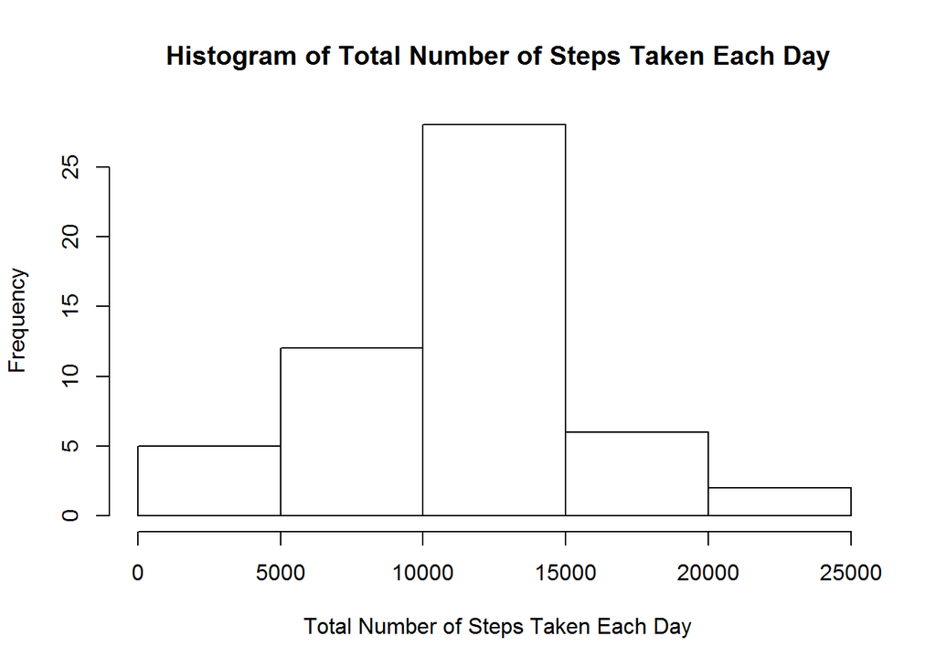

```r
Sum_day <- sapply(split(activity$steps, activity$date), sum)
hist(Sum_day, xlab = " Total Number of Steps Taken Each Day",
        main = " Histogram of Total Number of Steps Taken Each Day")
```

The mean is

```r
mean(Sum_day[!is.na(Sum_day)])
```

```
## [1] 10766.19
```

The median is

```r
median(Sum_day[!is.na(Sum_day)])
```

```
## [1] 10765
```

### What is the average daily activity pattern?

- calculate the average number of steps taken in each 5 minutes interval, averaged across all days
- Make a time series plot of the 5-minute interval (x-axis) and the average number of steps taken, averaged across all days (y-axis)
- find a 5-minute interval, contains the maximum number of steps

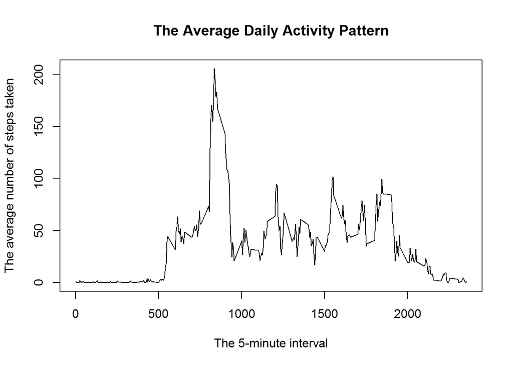

```r
p_activity <- activity[!is.na(activity$steps),]
mean_interval <- sapply(split(p_activity$steps, p_activity$interval), mean)
plot(names(mean_interval), mean_interval, type = "l", main = "The Average Daily Activity Pattern",
        xlab = "The 5-minute interval", ylab ="The average number of steps taken")
```

The 5 minute time interval is

```r
a <- max(mean_interval)
names(mean_interval[(mean_interval== a)])
```

```
## [1] "835"
```

### Imputing missing values

There are missing values, “NAs”, in the original data, the number of NAs is

```r
num_nas <- is.na(activity$steps)
sum(num_nas)
```

```
## [1] 2304
```

In order to avoid the bias introduced by the missing values, we device a strategy to fill in the missing data.

- Find the minssing values, NAs,
- Replace them by the the average number of steps taken in each 5 minutes interval, averaged across all days
- Calculate the total number of steps taken each day
- Make histgoram of the total number of steps taken each day
- Calculate and report the mean and median total number of steps taken per day

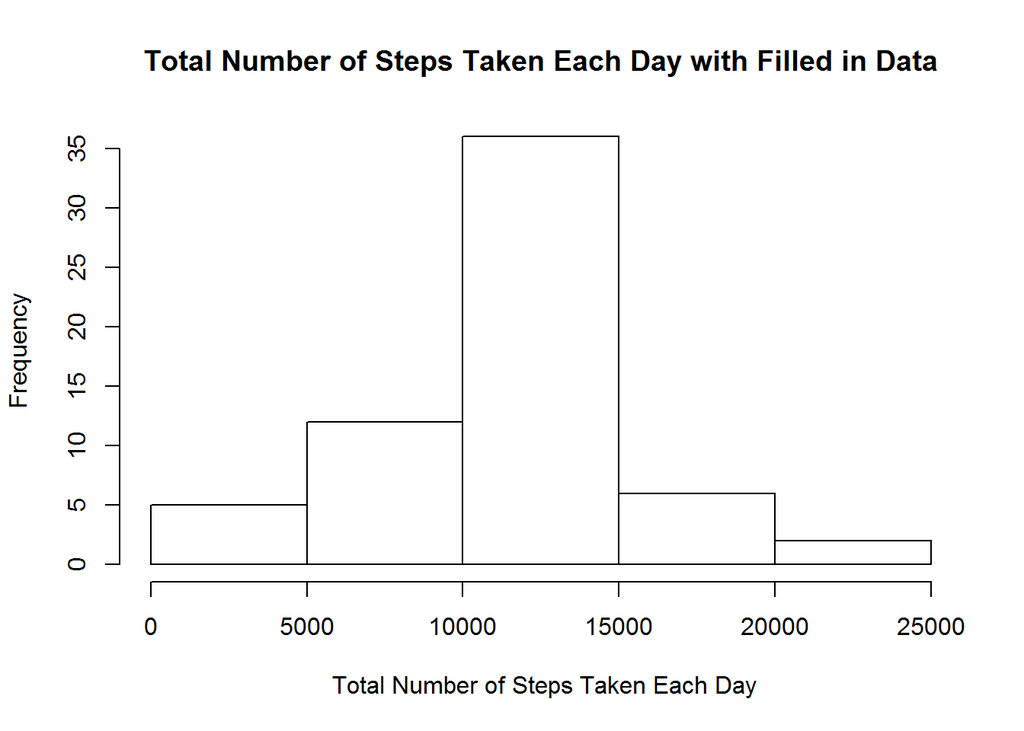

```r
new_activity <- lapply(split(activity$steps, activity$date),
                    function(x) if(is.na(sum(x))) x = as.numeric(mean_interval)
                                            else x=x)
library(reshape)
m <- melt(new_activity)
new_activity <- activity
new_activity$steps <- m[[1]]
new_day <- sapply(split(new_activity$steps, new_activity$date), sum)
hist(new_day, xlab = " Total Number of Steps Taken Each Day",
        main = "Total Number of Steps Taken Each Day with Filled in Data")
```

The new mean is

```r
mean(new_day[!is.na(new_day)])
```

```
## [1] 10766.19
```

The new median is

```r
median(new_day[!is.na(new_day)])
```

```
## [1] 10766.19
```

**The results show that**

- the outlines of the new histgorams are similar to the original one’s,
- the the two means are the same, but
- the new median equals to new mean and a little bit higher than the original median

### Are there differences in activity patterns between weekdays and weekends?

- Create two sub datasets, one is weekday dataset and another is weekend dataset
- Calculate the average number of steps taken in each 5 minutes interval, averaged across weekdaysand weekends
- Make a time series plot of the 5-minute interval (x-axis) and the average number of steps taken, averaged across weekdays and weekends(y-axis)

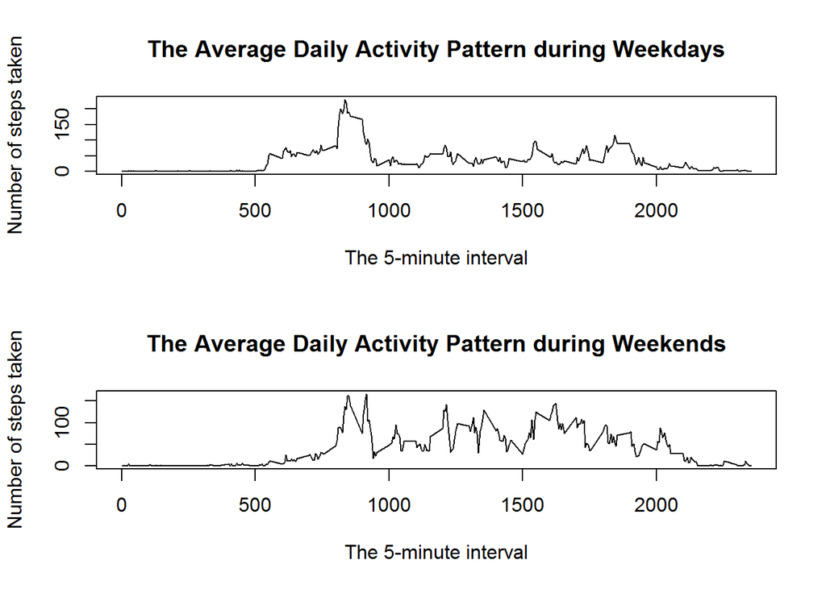

```r
w <- weekdays(as.Date(activity$date),abbreviate=TRUE)
new_activity$weekday <- w

par(mfrow = c(2, 1))

wk_activity = new_activity[grepl("周一|周二|周三|周四|周五", new_activity$weekday),]
wk_mean_interval <- sapply(split(wk_activity$steps, wk_activity$interval), mean)
plot(names(wk_mean_interval), wk_mean_interval, type = "l", main = "The Average Daily Activity Pattern during Weekdays",
        xlab = "The 5-minute interval", ylab ="Number of steps taken")

wkend_activity = new_activity[grepl("周六|周日", new_activity$weekday),]
wkend_mean_interval <- sapply(split(wkend_activity$steps, wkend_activity$interval), mean)
plot(names(wkend_mean_interval), wkend_mean_interval, type = "l", main = "The Average Daily Activity Pattern during Weekends",
        xlab = "The 5-minute interval", ylab ="Number of steps taken")
```

```r
par(mfrow = c(1, 1))
```

**The two patterns looks different.**